# Elk & Deer Connectivity

Michelle M. Fink

2024-02-13

# Overview

This notebook contains code used to explore the data available for training the permeability classification.  
It’s in various pieces and was used in conjunction with ArcPro (for visualization and reclassification) before bringing the resulting geotiffs back into R for the classification.

## Initial classification.

Using percentile breaks.

```r
train <- rast(file.path(projdir, "CPW_Data", "Elk_migs_by_DAU.tif"))
traindf <- spatSample(train, size=50000, method="random", na.rm=TRUE)
summary(traindf)
```

```
  Weighted.UDs
 Min.   :0.009736
 1st Qu.:0.023737
 Median :0.047474
 Mean   :0.078208
 3rd Qu.:0.095719
 Max.   :0.834283
```

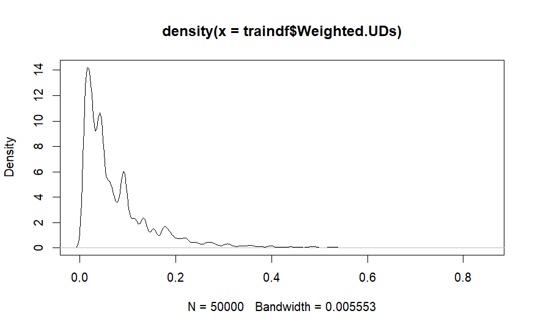

```r
plot(density(traindf$Weighted.UDs))
```

Various breaks were explored, e.g.:

```r
testbrks <- quantile(traindf$Weighted.UDs, probs=c(0.1,0.2,0.4,0.8,0.98))
testbrks
```

```
       10%        20%        40%        80%        98%
0.01195024 0.01986387 0.03894375 0.11783288 0.33768576
```

Normally I assign 10 permeability categories, but for this process, 5 classes of permeability seems to be the maximum practical number of categories. That may have to be reduced to 3, but so far I have stuck with 5. Once breaks have been determined, reclassify the raw data to 1 (least travelled) to 5 (most travelled). By the nature of the data, there is no “impermeable” classification at this stage, it will have to be added *post-hoc*.

**NOTE** It is *not* sufficient to just reclassify the data. We have been told that this data is generalized and covers more area than actual travel paths by the animals. Therefore, some additional steps need to be taken to make sure we’re not erroneously classifying certain land (and dataset) features as more permeable than they are.  
These steps were done in ArcPro, don’t try to run the chunks from here.

First step is to mask out areas of open water. The **phenology inputs** are at a coarser resolution, and so have very blobby waterbodies. Using those as the mask (remember this is just for the training classification).

```r
elktraintmp = arcpy.sa.SetNull(
    in_conditional_raster="DUR_17_22_mean.tif",
    in_false_raster_or_constant="Reclass_Elk", # reclassification done in ArcPro
    where_clause="VALUE = 1000"                # open water
)
```

Next mask out other land cover coded as barriers. I haven’t had luck nesting SetNull commands, so I do this separately.

```r
elktraintmp2 = arcpy.sa.SetNull(
    in_conditional_raster="landcover_rvsd.tif",
    in_false_raster_or_constant="elktraintmp",
    where_clause="Value = 999"                 # barriers (high traffic highways, wildlife fencing, etc)
)
```

Finally lower the permeability classification of areas that are recognized as ‘near-barriers’. These are coded in the land cover as values of >= 200 to < 999, with the higher values being progressively less permeable.

```r
elk_perm_train = Con(("landcover_rvsd.tif" >= 300) & ("elktraintmp2" > 3), "elktraintmp2" - 3, Con(("landcover_rvsd.tif" >= 200) & ("landcover_rvsd.tif" < 300) & ("elktraintmp2" > 3), 3, "elktraintmp2"))
```

Save that as a .tif and use in `permeability_classification.R`

## More advanced classification

**The Concern**: Alpine is not low-permeability, but the migration dataset has lower values at higher elevation. Therefore the classification results are not correct for Alpine (and other landscapes where there is less data).

**Why:** Elk are forced to be concentrated in Winter Habitat, but once elk are finished migrating to summer range, they spread out and stay in the alpine and subalpine.

**Exploration:** I created a stratified point sample over the **Elk_migs_byDAU.tif** dataset to look at elevation and/or latitudinal biases. (which I apparently did in ArcPro, because I don’t see it in my R history)

```r
indat <- fread(file.path(projdir, "ElkRun11Jan24_test.csv"))

indat[NED <= 1600, eRange := "Plains"][(NED > 1600) & (NED <= 2300), eRange := "LowerMontane"]
indat[(NED > 2300) & (NED <= 2800), eRange := "UpperMontane"]
indat[(NED > 2800) & (NED <= 3500), eRange := "Subalpine"][NED > 3500, eRange := "Alpine"]

fac <- c("Plains", "LowerMontane", "UpperMontane", "Subalpine", "Alpine")
indat[, eRange := factor(eRange, levels=fac)]
summary(indat)
```

```
      idx              x                y              Elk_migs             NED                eRange
 Min.   :    1   Min.   :203486   Min.   :4095214   Min.   :0.009736   Min.   :1553   Plains      :   22
 1st Qu.: 7140   1st Qu.:291026   1st Qu.:4261984   1st Qu.:0.023737   1st Qu.:2299   LowerMontane: 7142
 Median :14279   Median :326366   Median :4427014   Median :0.059751   Median :2599   UpperMontane:11528
 Mean   :14279   Mean   :340178   Mean   :4365904   Mean   :0.141661   Mean   :2632   Subalpine   : 8788
 3rd Qu.:21418   3rd Qu.:392996   3rd Qu.:4474624   3rd Qu.:0.189894   3rd Qu.:2930   Alpine      : 1077
 Max.   :28557   Max.   :486686   Max.   :4541254   Max.   :0.834283   Max.   :4098
```

*Elk_migs* = sampled values from Elk_migs_byDAU.tif  
*NED* = elevation in meters  
Total number of sample points = 28557  
*eRange* = Categorical elevation range. Ranges used:

```
Elevation ranges in CO
                                 Feet            Meters
---------------------------------------------------------
Plains                         < 5,249            < 1,600
Lower-Montane / Foothills   5,249 - 7,546       1,600 - 2,300
Upper Montane               7,546 - 9,186       2,300 - 2,800
Subalpine                   9,186 - 11,500      2,800 - 3,500
Alpine                       > 11,500            > 3,500
```

**Samples by Elevation Range:**

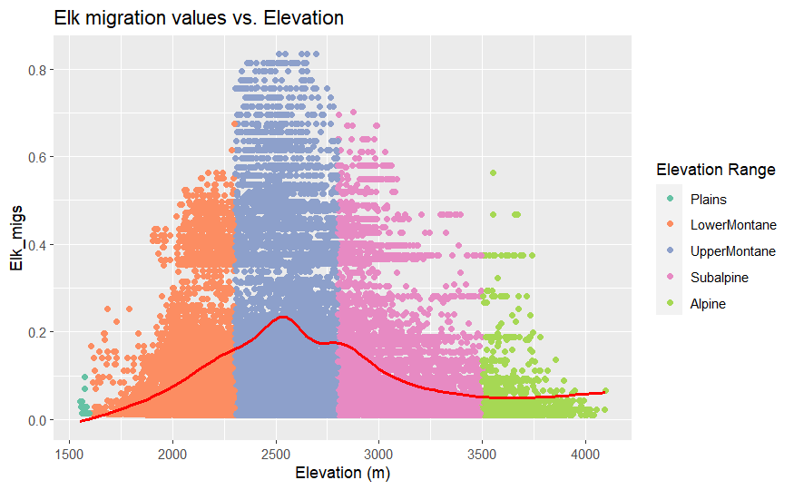

```r
e.rng <- ggplot(indat, aes(x=NED, y=Elk_migs))
e.rng + geom_point(aes(color=eRange)) +
  stat_smooth(span=0.33, se=FALSE, color="red") +
  scale_color_brewer(palette="Set2") +
  labs(title="Elk migration values vs. Elevation", color="Elevation Range",
       x="Elevation (m)")
```

Why yes, these are ghastly colors…

Values peak in the Upper Montane range.  
Digging deeper, we can look at Elk_migs vs. Elevation conditioned upon both latitude and longitude:

```r
indat[, X_UTM := cut_number(x, n=2)][, Y_UTM := cut_number(y, n=3)]
```

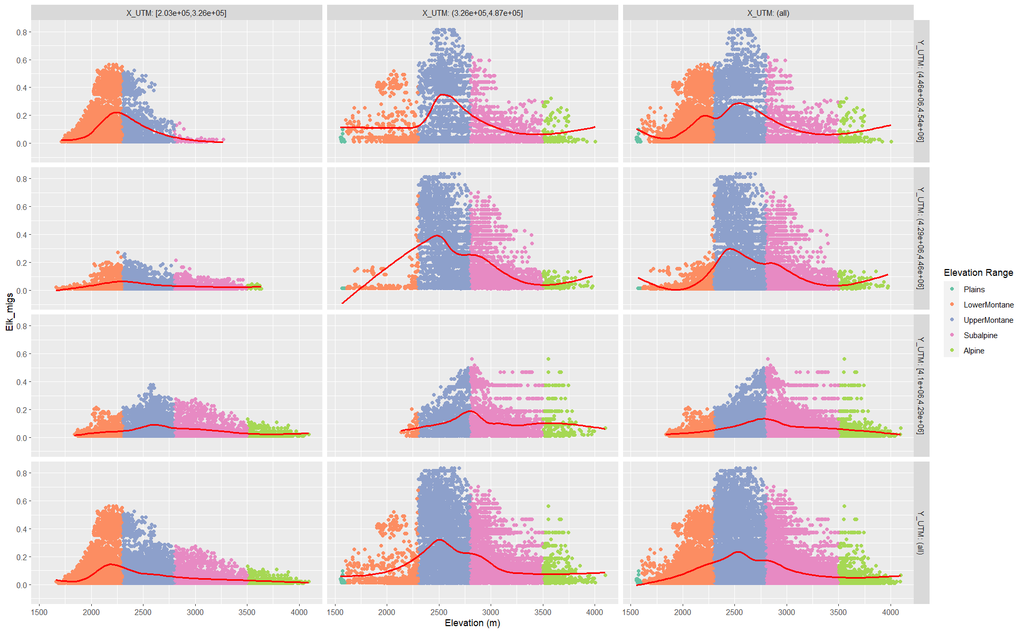

```r
e.rng  + geom_point(aes(color=eRange)) +
  stat_smooth(se=FALSE, color="red") +
  scale_color_brewer(palette="Set2") +
  facet_grid(rows=vars(Y_UTM),
             cols=vars(X_UTM),
             as.table=FALSE, labeller=label_both, margins=TRUE) +
  labs(color="Elevation Range", x="Elevation (m)")
```

I don’t like how the GAM smooth curves up at the edges, that isn’t what’s happening with the data. But anyway, I wound up stratifying the data by 2 longitude breaks and 3 latitude breaks, and classified high elevation areas differently in each. Is was a messy and iterative process, see the MindMap. I’ll have to write it out coherently soon, and will update the notebook then.

## Post-processing permeability layer

**Skipping over all the classification runs**  
Once you finally have a permeability layer you can move forward with, you need to make some *post-hoc* adjustments to add barriers and low permeability areas, as well as put in known large mammal under/over passes as highly permeable.

```r
env.mask = co_bnd.shp
elk3feb_masked = SetNull(("landcover_rvsd.tif" == 114) | ("landcover_rvsd.tif" == 999), Con(("landcover_rvsd.tif" >= 300) & ("landcover_rvsd.tif" < 999), 0.5, "ElkRun3_Feb24.tif"))

elk_Run3Feb24 = Con(IsNull("PermeabilityFactors_30m"), "elk3feb_masked", 5)
```